# Linear vs Binary Search Algorithm Performance Measurement

## Linear vs Binary Search

```python
# import required or possible modules for use
import numpy as np
import pandas as pd
import matplotlib.pyplot as plt
import seaborn as sns
from timeit import default_timer as timer
import math
import random
```

The following two cells contain the linear search function and binary search function. Each function's performance will be measured on a set of five randomly constructed arrays of various lengths. The linear search function searches an array one item at a time, the binary search function splits the data in halves and searches in a non-linear manner.

```python
# linear search function
def lin_search(arr, tgt):
    for i in arr:
        if i == tgt:
            return np.where(arr == tgt)
    return None
```

```python
# binary search function
def binary_search(arr, tgt):
    low = 0
    high = len(arr) - 1
    while low <= high:
        mid = math.floor((low + high) / 2)
        guess = arr[mid]
        if guess == tgt:
            return mid
        if guess > tgt:
            high = mid - 1
        else:
            low = mid + 1
    return None
```

The following cells create the five random arrays of various lengths. Following the arrays is a list of the arrays and lists for tracking performance and the length of each array. The list of arrays will be used in a loop to test the search functions' performance.

```python
# create 5 arrays of random sizes, seed set at 32 for all
random.seed(32)
a = np.random.randint(low=1, high=2000, size=704)
```

```python
random.seed(32)
b = np.random.randint(low=1, high=2000, size=237)
```

```python
random.seed(32)
c = np.random.randint(low=1, high=2000, size=498)
```

```python
random.seed(32)
d = np.random.randint(low=1, high=2000, size=125)
```

```python
random.seed(32)
e = np.random.randint(low=1, high=2000, size=606)
```

```python
# create list of the arrays for a loop
arrays = [a,b,c,d,e]
```

```python
# lists for tracking data
lengths = []
sort_times = []
lin_srch_times = []
bin_srch_times = []
```

The following cell loops through each array from the arrays list. The array's length is captured, and the performance of the linear search and binary search are measured. The performance data and arrays' length is appended to the data tracking lists in the above cell.

```python
# loop through each array and gather performance data
for item in arrays:
    length = len(item)
    lengths.append(length)
    start1 = timer()
    item.sort()
    end1 = timer()
    sort_speed = (end1 - start1) * 1000
    sort_times.append(sort_speed)
    tgt = max(item)
    start2 = timer()
    lin_search(item, tgt)
    end2 = timer()
    lin_srch_speed = (end2 - start2) * 1000
    lin_srch_times.append(lin_srch_speed)
    start3 = timer()
    binary_search(item, tgt)
    end3 = timer()
    bin_srch_speed = (end3 - start3) * 1000
    bin_srch_times.append(bin_srch_speed)
```

```python
# create a df for analysis of results
data = list(zip(lengths, sort_times, lin_srch_times, bin_srch_times))
df = pd.DataFrame(data, columns=['Array_Length','Sort_Time','Linear_Search_Time','Binary_Search_Time'])
df['Linear_Search_Sort'] = df['Sort_Time'] + df['Linear_Search_Time']
df['Binary_Search_Sort'] = df['Sort_Time'] + df['Binary_Search_Time']
df
```

|  | Array_Length | Sort_Time | Linear_Search_Time | Binary_Search_Time | Linear_Search_Sort | Binary_Search_Sort |
| --- | --- | --- | --- | --- | --- | --- |
| 0 | 704 | 0.0568 | 0.2831 | 0.0440 | 0.3399 | 0.1008 |
| 1 | 237 | 0.0140 | 0.0990 | 0.0260 | 0.1130 | 0.0400 |
| 2 | 498 | 0.0266 | 0.1853 | 0.0271 | 0.2119 | 0.0537 |
| 3 | 125 | 0.0093 | 0.0614 | 0.0235 | 0.0707 | 0.0328 |
| 4 | 606 | 0.0319 | 0.2379 | 0.0294 | 0.2698 | 0.0613 |

The above cell is a dataframe will all the array lengths, performance times for each function on each array, and the sort times plus performance times per function. Below are scatterplot visualizations which capture performance based on the array size.

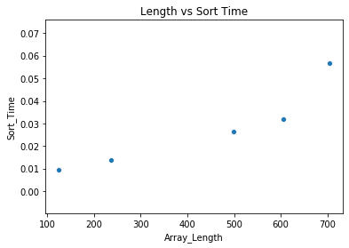

```python
# scatterplots to visualize results
sns.scatterplot(x = df['Array_Length'], y = df['Sort_Time']).set_title('Length vs Sort Time')
plt.show()
```

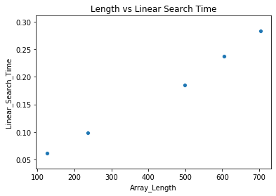

```python
sns.scatterplot(df['Array_Length'], df['Linear_Search_Time']).set_title('Length vs Linear Search Time')
plt.show()
```

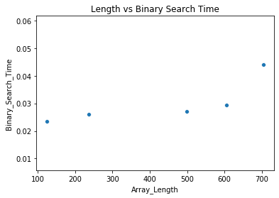

```python
sns.scatterplot(df['Array_Length'], df['Binary_Search_Time']).set_title('Length vs Binary Search Time')
plt.show()
```

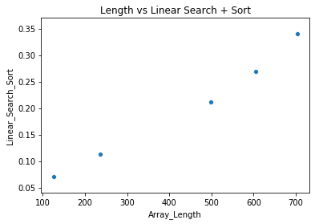

```python
sns.scatterplot(df['Array_Length'], df['Linear_Search_Sort']).set_title('Length vs Linear Search + Sort')
plt.show()
```

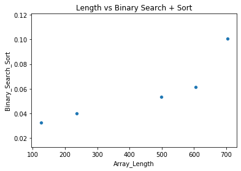

```python
sns.scatterplot(df['Array_Length'], df['Binary_Search_Sort']).set_title('Length vs Binary Search + Sort')
plt.show()
```

## Executive Summary

In this experiment we tested the built-in sort function, user defined linear search function, and user defined binary search function. I have provided a data table (dataframe) that provides the processing speed results of each operation in milliseconds. The scatterplots below the data table also visualize the results of the experiment.

The table and visualizations demonstrate the improvement in search speed for the binary search function as opposed to the linear search function. While the time increases as the array size increases, the difference in search times between the linear function and the binary function are significant, especially as the array size increases. In the largest array of 704 items, the linear search time is ~.28 milliseconds while the binary search time is ~.04 milliseconds. In contrast, referring to the shortest array with 125 items, the linear search time is ~.06 milliseconds while the binary search time is ~.02 milliseconds. This variance in performance captures how as the array grows in size, the performance gap of each search algorithm drastically favors the binary search. As for the sort function, the processing speed grows in a relatively linear fashion as the size of the array increases.

The binary search function speeds up the process of finding a target value in the array by cutting the array in half as it searches; it partitions the data (after being sorted) based on a greater than or less than method to more quickly find the target. It begins from an initial split, then a new split within the initial split, and so on until it has honed in on the target variable.

In BigO notation, the binary search function is measured as O(log n); the natural logarithm of n, with n representing the length of the array. This is also known as log time. As for the speed of the linear search function, it is measured as O(n), or linear time; the speed is based on the length of the array. The sort() function is a built in Python function. In BigO notation, the sort function is measured as O(n log n). This is a fast sorting algorithm.

The binary search function is useful to data engineers as they can optimize data processing functions at a faster rate, as opposed to linear time. The processing time for large amounts of data using linear time techniques would severely slow down our systems as the data increases. The processing time for large amounts of data using a log time technique increases its advantage over a linear time technique as the data grows.